# Statistical Testing

### Statistical testing for state Fractional Occupancy (FO).

1. Interaction effect between states and conditions, suggesting that the FO of the 4 states are different among conditions.

```r
# Two-way anova
mod_anova <- lm(FO ~ Condition + K, sdf3)
# Interaction model
mod_intr <- lm(FO ~ Condition * K, sdf3)

res <- residuals(mod_intr)- residuals(mod_anova)

anova(mod_anova, mod_intr,
      test='Chisq')
```

```
Analysis of Variance Table

Model 1: FO ~ Condition + K
Model 2: FO ~ Condition * K
  Res.Df    RSS Df Sum of Sq  Pr(>Chi)
1    313 24.953
2    304 14.880  9    10.074 < 2.2e-16 ***
---
Signif. codes:  0 ‘***’ 0.001 ‘**’ 0.01 ‘*’ 0.05 ‘.’ 0.1 ‘ ’ 1
```

```r
print(paste('AIC is reduced by', as.character(AIC(mod_anova) - AIC(mod_intr))))
```

```
[1] "AIC is reduced by 147.444551787753"
```

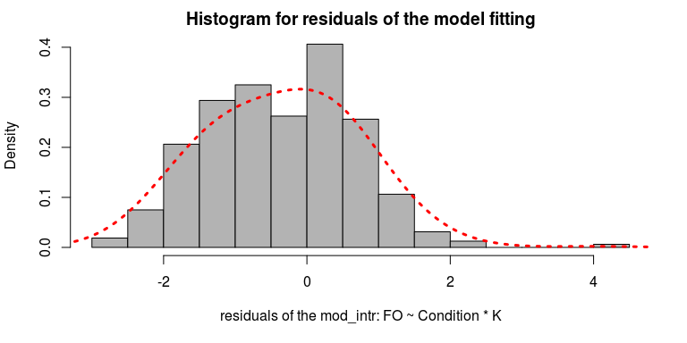

```r
# Interaction model
mod_intr <- glm(FO ~ Condition * K, sdf3, family=Gamma(link='identity'))
#anova(mod_intr)
res_intr <- residuals(mod_intr)
hist(res_intr, prob=TRUE, col='grey70',
     main='Histogram for residuals of the model fitting',
     xlab='residuals of the mod_intr: FO ~ Condition * K')
lines(density(res_intr, adjust=2), col='red', lty='dotted', lwd=3)
```

2. Permutation tests for pair-wise comparison of state FO within conditions

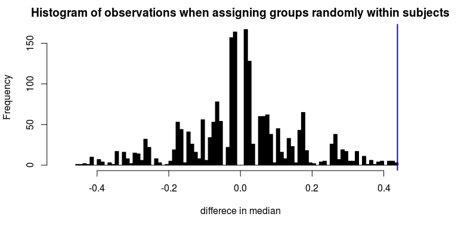

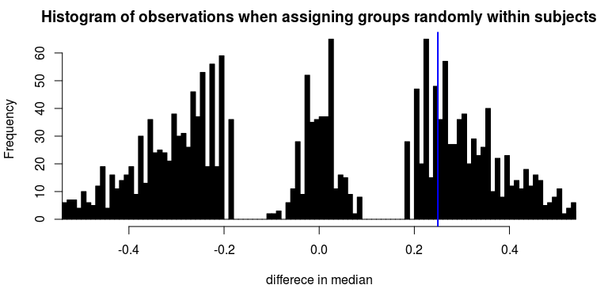

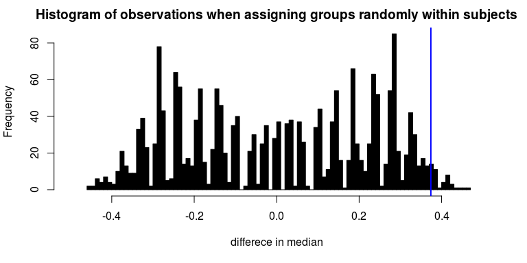

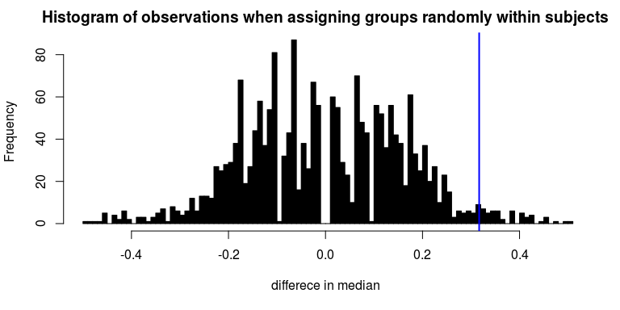

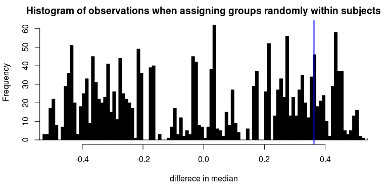

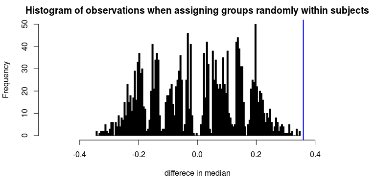

```r
ordered_conditions <- c('BR_dominant', 'BR_mixed', 'Rpl_smt_dominant','Rpl_smt_mixed')

within_conditions <- c('BR_dominant', 'BR_mixed', 'BR_mixed','Rpl_smt_dominant', 'Rpl_smt_dominant','Rpl_smt_mixed')
contrasted_pairs <- matrix(c('FO.K1','FO.K4',
                             'FO.K2','FO.K3',
                             'FO.K1','FO.K3',
                             'FO.K1','FO.K2',
                             'FO.K2','FO.K3',
                             'FO.K1','FO.K4'), nrow=2)

P <- c()

for(c in 1:length(within_conditions)){

  # extract compared conditions
  contrasted_pair = contrasted_pairs[,c]
  within_condition = within_conditions[c]

celldat <- sdf3 %>% filter(Condition == within_condition &
                             K %in% contrasted_pair) %>% select(Condition, Subject, K, FO)

# decide order
diff_median <- diff(c(median(celldat$FO[celldat$K==contrasted_pair[1]]), median(celldat$FO[celldat$K==contrasted_pair[2]])))
Kstr <- str_remove(contrasted_pair,'FO.K')
Knum <- as.numeric(Kstr)
bigK <- ifelse(diff_median>0, Kstr[2], Kstr[1])

true_class <- ifelse(grepl(bigK, celldat$K),1,0)
n <- 20
div <- length(true_class)/(2*n)

fo <- celldat$FO
true_diff <- diff(by(fo, true_class, median))/div # becuase the contrast is even, so taking difference and then mean is the same as taking the differnce of the mean
dist_diff = c()
set.seed(1)
permutation_N <- 2000

for (i in 1:permutation_N){
# notice that the permutation is paired, so only exchange within the subjects
rand_binomial <- rbinom(n, 1, 0.5)
rand_binomial_paired <- abs(1-rand_binomial)

rand_sample <- matrix(data=NA, nrow=1, ncol=div*n)
rand_sample[true_class==1]=rep(rand_binomial, each=div) #rand_binomial
rand_sample[true_class==0]=rep(rand_binomial_paired, each=div) #rand_binomial_paired
rand_sample <- as.numeric(rand_sample)

dist_diff[i] <- diff(by(fo, rand_sample, median))/div
}

#r plot permutation result
hist(dist_diff, xlim = c(-0.5, 0.5), col = "black", breaks = 100, main='Histogram of observations when assigning groups randomly within subjects', xlab="differece in median")
abline(v = true_diff, col = "blue", lwd = 2)
true_diff
if (sum(dist_diff > true_diff)/permutation_N < 0.5){p = sum(dist_diff > true_diff)/permutation_N}else{
  p = sum(dist_diff < true_diff)/permutation_N}
p

# write variables;dodge is for plotting
#P[c] <- paste0('p=', format(round(p, 3), nsmall = 3))
P[c] <-  format(round(p, 2), nsmall = 2)


}
```

```r
P_adjust<-format(round(p.adjust(P, method='fdr'), 2), nsmall = 2)
P_adjust
```

```
[1] "0.00" "0.29" "0.04" "0.04" "0.20" "0.00"
```

### Statistical exploration for the relationship of the State-4 lifetime and the perceptual duration during BR

1. Mixed linear model for trial-by-trial prediction. For m0 and m1, the condition type or the State-4 lifetime was used to fit the first-level (within-subject) model, and its slope is allowed to vary across subjects but is assumed to centre around a fixed value. For m2, the random ractor is the interval, while the condition type and State-4 lifetime are fixed factors.

```r
df_br <- df %>% filter(grepl('BR', Condition)) %>% mutate(life.K4.second = life.K4/250)

m0 <- lmer(Y.Lat_before ~ Condition + (Condition|cond.sub), df_br)
m1 <- lmer(Y.Lat_before ~ Condition + life.K4.second + (life.K4.second|cond.sub), df_br)
m2 <- lmer(Y.Lat_before ~ Condition + life.K4.second + (1|cond.sub), df_br)

summary(m0)
```

```
Linear mixed model fit by REML ['lmerMod']
Formula: Y.Lat_before ~ Condition + (Condition | cond.sub)
   Data: df_br

REML criterion at convergence: 46488.6

Scaled residuals:
    Min      1Q  Median      3Q     Max
-2.9582 -0.4573 -0.1624  0.2996 11.4258

Random effects:
 Groups   Name              Variance Std.Dev. Corr
 cond.sub (Intercept)       0.04014  0.2003
          ConditionBR_mixed 0.33387  0.5778   -0.21
 Residual                   1.30155  1.1409
Number of obs: 14943, groups:  cond.sub, 20

Fixed effects:
                  Estimate Std. Error t value
(Intercept)        0.67102    0.04677   14.35
ConditionBR_mixed  1.85244    0.13066   14.18

Correlation of Fixed Effects:
            (Intr)
CndtnBR_mxd -0.230
```

```r
summary(m1)
```

```
Linear mixed model fit by REML ['lmerMod']
Formula: Y.Lat_before ~ Condition + life.K4.second + (life.K4.second |      cond.sub)
   Data: df_br

REML criterion at convergence: 46911.7

Scaled residuals:
    Min      1Q  Median      3Q     Max
-2.8393 -0.5177 -0.1581  0.3381 11.1049

Random effects:
 Groups   Name           Variance Std.Dev. Corr
 cond.sub (Intercept)    0.2569   0.5069
          life.K4.second 0.8718   0.9337   -0.89
 Residual                1.3382   1.1568
Number of obs: 14943, groups:  cond.sub, 20

Fixed effects:
                  Estimate Std. Error t value
(Intercept)        0.89022    0.11892   7.486
ConditionBR_mixed  1.60679    0.03581  44.866
life.K4.second    -0.17461    0.21757  -0.803

Correlation of Fixed Effects:
            (Intr) CndBR_
CndtnBR_mxd -0.276
lif.K4.scnd -0.886  0.210
```

```r
summary(m2)
```

```
Linear mixed model fit by REML ['lmerMod']
Formula: Y.Lat_before ~ Condition + life.K4.second + (1 | cond.sub)
   Data: df_br

REML criterion at convergence: 47349.7

Scaled residuals:
    Min      1Q  Median      3Q     Max
-2.5025 -0.5483 -0.1658  0.3535 10.8811

Random effects:
 Groups   Name        Variance Std.Dev.
 cond.sub (Intercept) 0.09555  0.3091
 Residual             1.38382  1.1764
Number of obs: 14943, groups:  cond.sub, 20

Fixed effects:
                  Estimate Std. Error t value
(Intercept)        0.95276    0.07707  12.362
ConditionBR_mixed  1.52457    0.03470  43.930
life.K4.second    -0.34879    0.04851  -7.191

Correlation of Fixed Effects:
            (Intr) CndBR_
CndtnBR_mxd -0.404
lif.K4.scnd -0.406  0.831
```

```r
anova(m0, m1, m2)
```

```
refitting model(s) with ML (instead of REML)
```

```
Data: df_br
Models:
m2: Y.Lat_before ~ Condition + life.K4.second + (1 | cond.sub)
m0: Y.Lat_before ~ Condition + (Condition | cond.sub)
m1: Y.Lat_before ~ Condition + life.K4.second + (life.K4.second |
m1:     cond.sub)
   npar   AIC   BIC logLik deviance  Chisq Df Pr(>Chisq)
m2    5 47346 47384 -23668    47336
m0    6 46494 46540 -23241    46482 853.95  1     <2e-16 ***
m1    7 46916 46969 -23451    46902   0.00  1          1
---
Signif. codes:  0 ‘***’ 0.001 ‘**’ 0.01 ‘*’ 0.05 ‘.’ 0.1 ‘ ’ 1
```

2. ANCOVA model for individual-averaged values (i.e., variance provided by individual differences), hence the prediction is made on the group level.

```r
sdf_BR_K4 <- sdf_clean %>% filter(grepl('BR', conditions) & states=='K4')

mod0 <- glm(Y.Lat_before ~ conditions, sdf_BR_K4, family=Gamma(link='identity'))
mod1 <- glm(Y.Lat_before ~ state_lifetime_second*conditions, sdf_BR_K4, family=Gamma(link='identity'))
mod2 <- glm(Y.Lat_before ~ state_lifetime_second+conditions, sdf_BR_K4, family=Gamma(link='identity'))

AIC(mod0, mod1, mod2)
```

|  | df | AIC |
| --- | --- | --- |
| mod0 | 3 | 37.51856 |
| mod1 | 5 | 36.49375 |
| mod2 | 4 | 35.02965 |

```r
summary(mod2)
```

```
Call:
glm(formula = Y.Lat_before ~ state_lifetime_second + conditions,
    family = Gamma(link = "identity"), data = sdf_BR_K4)

Deviance Residuals:
     Min        1Q    Median        3Q       Max
-0.72769  -0.17746  -0.03903   0.14382   0.44990

Coefficients:
                      Estimate Std. Error t value Pr(>|t|)
(Intercept)            0.79608    0.07597  10.479 1.26e-12 ***
state_lifetime_second -0.37760    0.16585  -2.277   0.0287 *
conditionsBR (mixed)   1.74784    0.16662  10.490 1.22e-12 ***
---
Signif. codes:  0 ‘***’ 0.001 ‘**’ 0.01 ‘*’ 0.05 ‘.’ 0.1 ‘ ’ 1

(Dispersion parameter for Gamma family taken to be 0.07223538)

    Null deviance: 19.6189  on 39  degrees of freedom
Residual deviance:  2.9067  on 37  degrees of freedom
AIC: 35.03

Number of Fisher Scoring iterations: 5
```

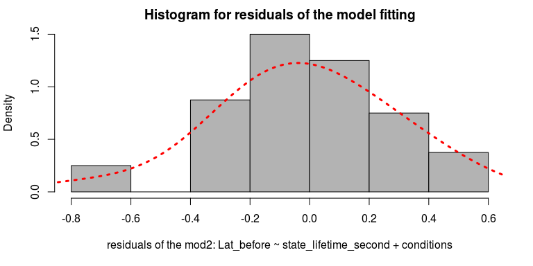

```r
residual_ancova<-residuals(mod2)
hist(residual_ancova, prob=TRUE, col='grey70',
     main='Histogram for residuals of the model fitting',
     xlab='residuals of the mod2: Lat_before ~ state_lifetime_second + conditions')
lines(density(residual_ancova, adjust=2), col='red', lty='dotted', lwd=3)
```

```r
tbl2<-read_csv('/media/dian/D/data/Binocular_Rivalry/HMM_analyses/output_test/embedded_lag/DMN_V1_1000_100_K4_pca16/GC_bhv_table2.csv')
tblF <- read_csv('/media/dian/D/data/Binocular_Rivalry/HMM_analyses/output_test/embedded_lag/DMN_V1_1000_100_K4_pca16/run1_analyses/Ftable.csv')
dat <- cbind(tbl2, tblF)
dat = dat[(!is.nan(dat$stable_before)) & (dat$dBIC_pcu< -5),]

dat$dBIC_pcu_log <- log(-1*(dat$dBIC_pcu))

dat2<- dat %>% mutate(LFT_cat =
                        case_when(
                          k4_life>250*0.95 ~ "0.95s < State 4",
                          k4_life<=250*0.95 &  k4_life > 250*0.7 ~ "0.7s < State 4 <= 0.95s",
                          k4_life<=250*0.7 &  k4_life > 250*0.6 ~ "0.6s < State 4 <= 0.7s",
                          k4_life<=250*0.6 &  k4_life > 250*0.5 ~ "0.5s < State 4 <= 0.6s",
                          k4_life <= 250*0.5 ~ "State 4 <= 0.5s"
                        )
                        ) %>% mutate(rate=lat_before+stable_before)


withinsub_mat <- matrix(data = NA, nrow=20*length(unique(dat2$LFT_cat)), ncol=ncol(dat2)-2)
SubList <- c()
LFT_cat <- c()

n<-0
for (ss in 1:20){
  for (c_lft in unique(dat2$LFT_cat)){
  n <- n+1
  subj <- paste0('S', str_pad(ss, 2 ,pad='0'))
  LFT_cat[n] <- c_lft
  stbl<-dat2 %>% filter(sub==subj & LFT_cat==c_lft) %>% select(-LFT_cat, -sub)
stbl.mean <- sapply(stbl, function(stbl) mean(na.omit(stbl)))
withinsub_mat[n,] <- stbl.mean
SubList[n] <- subj
}
}

# assembly
colnames(withinsub_mat) <- names(stbl)
GC_withinsub_df <- as.data.frame(withinsub_mat) %>% mutate(k4_second = k4_life/250)
GC_withinsub_df$Subject  <- SubList
GC_withinsub_df$life_time_category <- LFT_cat

GC_withinsub_df2 <- GC_withinsub_df %>% mutate(k4_lifetime_order = case_when(
                          LFT_cat== "0.95s < State 4" ~5,
                          LFT_cat== "0.7s < State 4 <= 0.95s"~4,
                          LFT_cat== "0.6s < State 4 <= 0.7s"~3,
                          LFT_cat== "0.5s < State 4 <= 0.6s"~2,
                          LFT_cat== "State 4 <= 0.5s"~ 1
                        )) %>% filter(LFT_cat != "State 4 <= 0.5s")  %>% na.omit()
```

### Statistical testing for the relationship between the Granger causality (GC) from PCU to V1 and the perceptual duration of the last dominant percept for BR (dominant) trials

1. Mixed linear model with the first-level model fitting for each subject and the interval is the random effect. The specified models are meant to address the question: whether the GC(PCU->V1) indicates an elevated level of endogenous attention or global adaptation. In the former case, GC is hypothesised to speed up the perceptual transition, therefore it should be negatively correlated with the mixed perceptual duration before settling on a new dominant percept (var: lat_before). This situation is modelled as the mdl1. In the latter case when GC (PCU->V1) indicates global adaptation of a dominant percept, the GC should be predicted by the length of the last dominant percept before a perceptual transition (var: stable_before). This case is modelled by the mdl2. Since we already knew that there was a relationship between the State-4 lifetime and the duration before a perceptual change (lat_before), so we also modelled in the same way for the State-4 lifetime as a reference/comparison to the GC. Unfortunately, the result is not significant for either of the hypotheses. GC (PCU->V1) does not have the predictive power for the trial-by-trial prediction of perceptual durations.

```r
mdl1 <- lmer(lat_before ~ dBIC_pcu_log + (1|sub), dat2)
mdl2 <- lmer(dBIC_pcu_log ~ stable_before + (1|sub), dat2)
mdl3 <- lmer(lat_before ~ k4_life + (1|sub), dat2)
mdl4 <- lmer(k4_life ~ stable_before + (1|sub), dat2)

summary(mdl1)
```

```
Linear mixed model fit by REML ['lmerMod']
Formula: lat_before ~ dBIC_pcu_log + (1 | sub)
   Data: dat2

REML criterion at convergence: 8853.2

Scaled residuals:
    Min      1Q  Median      3Q     Max
-1.3542 -0.5249 -0.2551  0.1339 10.6593

Random effects:
 Groups   Name        Variance Std.Dev.
 sub      (Intercept) 0.04792  0.2189
 Residual             0.70728  0.8410
Number of obs: 3530, groups:  sub, 20

Fixed effects:
              Estimate Std. Error t value
(Intercept)   0.684353   0.083738   8.173
dBIC_pcu_log -0.004098   0.016909  -0.242

Correlation of Fixed Effects:
            (Intr)
dBIC_pcu_lg -0.790
```

```r
summary(mdl2)
```

```
Linear mixed model fit by REML ['lmerMod']
Formula: dBIC_pcu_log ~ stable_before + (1 | sub)
   Data: dat2

REML criterion at convergence: 9424.6

Scaled residuals:
    Min      1Q  Median      3Q     Max
-3.6793 -0.6276  0.1479  0.7326  3.0159

Random effects:
 Groups   Name        Variance Std.Dev.
 sub      (Intercept) 0.1487   0.3856
 Residual             0.6994   0.8363
Number of obs: 3767, groups:  sub, 20

Fixed effects:
              Estimate Std. Error t value
(Intercept)   3.904985   0.090813  43.000
stable_before 0.001237   0.009587   0.129

Correlation of Fixed Effects:
            (Intr)
stable_befr -0.267
```

```r
summary(mdl3)
```

```
Linear mixed model fit by REML ['lmerMod']
Formula: lat_before ~ k4_life + (1 | sub)
   Data: dat2

REML criterion at convergence: 8856.1

Scaled residuals:
    Min      1Q  Median      3Q     Max
-1.3924 -0.5208 -0.2471  0.1319 10.6806

Random effects:
 Groups   Name        Variance Std.Dev.
 sub      (Intercept) 0.06321  0.2514
 Residual             0.70532  0.8398
Number of obs: 3530, groups:  sub, 20

Fixed effects:
             Estimate Std. Error t value
(Intercept) 0.5403399  0.0797356   6.777
k4_life     0.0007803  0.0003302   2.363

Correlation of Fixed Effects:
        (Intr)
k4_life -0.682
```

```r
summary(mdl4)
```

```
Linear mixed model fit by REML ['lmerMod']
Formula: k4_life ~ stable_before + (1 | sub)
   Data: dat2

REML criterion at convergence: 38464.4

Scaled residuals:
    Min      1Q  Median      3Q     Max
-5.0999 -0.4920  0.0850  0.5234  3.6012

Random effects:
 Groups   Name        Variance Std.Dev.
 sub      (Intercept) 5209     72.17
 Residual             1543     39.29
Number of obs: 3767, groups:  sub, 20

Fixed effects:
              Estimate Std. Error t value
(Intercept)   162.9722    16.1940  10.064
stable_before   0.5531     0.4511   1.226

Correlation of Fixed Effects:
            (Intr)
stable_befr -0.071
```

```r
AIC(mdl1, mdl2, mdl3, mdl4)
```

|  | df | AIC |
| --- | --- | --- |
| mdl1 | 4 | 8861.214 |
| mdl2 | 4 | 9432.591 |
| mdl3 | 4 | 8864.137 |
| mdl4 | 4 | 38472.439 |

2. Maybe the GC effect is bound to the State 4; therefore, here we are testing the relationship between the GC and perceptual duration only in trials with the majority (>95%) of the timepoint being visited by the State-4 neural dynamics. The model fitting is clearly improved, however, the null hypotheses are still better.

```r
dat2_g4 <- filter(dat2, LFT_cat == '0.95s < State 4') %>% na.omit()
mdl0.1 <- lmer(lat_before ~ 1 + (1|sub), dat2_g4)
mdl0.2 <- lmer(dBIC_pcu_log ~ 1 + (1|sub), dat2_g4)
mdl1.0 <- lmer(lat_before ~ dBIC_pcu_log + (1|sub), dat2_g4)
mdl1.1 <- lmer(lat_before ~ dBIC_pcu_log + (dBIC_pcu_log|sub), dat2_g4)
```

```
boundary (singular) fit: see ?isSingular
```

```r
mdl2 <- lmer(dBIC_pcu_log ~ stable_before + (1|sub), dat2_g4)


AIC(mdl1.0, mdl1.1, mdl2, mdl0.1, mdl0.2)
```

|  | df | AIC |
| --- | --- | --- |
| mdl1.0 | 4 | 1501.974 |
| mdl1.1 | 6 | 1505.958 |
| mdl2 | 4 | 2175.833 |
| mdl0.1 | 3 | 1495.280 |
| mdl0.2 | 3 | 2169.128 |

```r
summary(mdl1.0)
```

```
Linear mixed model fit by REML ['lmerMod']
Formula: lat_before ~ dBIC_pcu_log + (1 | sub)
   Data: dat2_g4

REML criterion at convergence: 1494

Scaled residuals:
    Min      1Q  Median      3Q     Max
-1.4145 -0.4970 -0.2382  0.1216  6.9181

Random effects:
 Groups   Name        Variance Std.Dev.
 sub      (Intercept) 0.0391   0.1977
 Residual             0.3072   0.5542
Number of obs: 882, groups:  sub, 13

Fixed effects:
             Estimate Std. Error t value
(Intercept)   0.64369    0.11034   5.834
dBIC_pcu_log -0.02315    0.02296  -1.008

Correlation of Fixed Effects:
            (Intr)
dBIC_pcu_lg -0.824
```

```r
summary(mdl1.1)
```

```
Linear mixed model fit by REML ['lmerMod']
Formula: lat_before ~ dBIC_pcu_log + (dBIC_pcu_log | sub)
   Data: dat2_g4

REML criterion at convergence: 1494

Scaled residuals:
    Min      1Q  Median      3Q     Max
-1.4221 -0.4971 -0.2391  0.1202  6.9124

Random effects:
 Groups   Name         Variance  Std.Dev. Corr
 sub      (Intercept)  4.347e-02 0.208502
          dBIC_pcu_log 8.038e-06 0.002835 -1.00
 Residual              3.072e-01 0.554224
Number of obs: 882, groups:  sub, 13

Fixed effects:
             Estimate Std. Error t value
(Intercept)   0.64514    0.11207   5.756
dBIC_pcu_log -0.02358    0.02295  -1.027

Correlation of Fixed Effects:
            (Intr)
dBIC_pcu_lg -0.831
convergence code: 0
boundary (singular) fit: see ?isSingular
```

3. Again, we sorted to group-level correlation between the GC, State-4 lifetime and the perceptual duration. When in comes to the individual-averaged values, there is no point to separate the last stable percept and the current mixed percept, because when taking an individual average, these two values are highly correlated. Therefore, here we only modeled for the averaged duration of the “last” dominant percept within-subject, which is almost equal to the average of all his/her dominant percepts. It can also be seen as an index of the speed/rate of BR transitions of a subject.

```r
mod_GC_regr <- glm(stable_before ~ dBIC_pcu_log + k4_lifetime_order, GC_withinsub_df2, family=Gamma(link="identity"))
mod_GC_intr <- glm(stable_before ~ dBIC_pcu_log * k4_lifetime_order, GC_withinsub_df2, family=Gamma(link="identity"))
AIC(mod_GC_regr, mod_GC_intr)
```

|  | df | AIC |
| --- | --- | --- |
| mod_GC_regr | 4 | 129.5677 |
| mod_GC_intr | 5 | 125.0232 |

```r
summary(mod_GC_intr)
```

```
Call:
glm(formula = stable_before ~ dBIC_pcu_log * k4_lifetime_order,
    family = Gamma(link = "identity"), data = GC_withinsub_df2)

Deviance Residuals:
     Min        1Q    Median        3Q       Max
-0.89159  -0.14444  -0.05897   0.11157   0.53899

Coefficients:
                               Estimate Std. Error t value Pr(>|t|)
(Intercept)                     -1.8489     1.8691  -0.989  0.32683
dBIC_pcu_log                     1.1842     0.4618   2.564  0.01304 *
k4_lifetime_order                1.4971     0.5362   2.792  0.00715 **
dBIC_pcu_log:k4_lifetime_order  -0.3942     0.1311  -3.007  0.00395 **
---
Signif. codes:  0 ‘***’ 0.001 ‘**’ 0.01 ‘*’ 0.05 ‘.’ 0.1 ‘ ’ 1

(Dispersion parameter for Gamma family taken to be 0.06298777)

    Null deviance: 4.2203  on 59  degrees of freedom
Residual deviance: 3.7201  on 56  degrees of freedom
AIC: 125.02

Number of Fisher Scoring iterations: 9
```

[figure not shown]

```r
res_GC_intr <- residuals(mod_GC_intr)
hist(res_GC_intr, prob=TRUE, col='grey70',
     main='Histogram for residuals of the model fitting',
     xlab='residuals of the mod_GC_intr: stable_before ~ dBIC_pcu_log * k4_second')
lines(density(residual_ancova, adjust=1.5), col='red', lty='dotted', lwd=3)
```

```r
GC_withinsub_df2_g4 <- GC_withinsub_df2 %>%  filter(life_time_category == "0.95s < State 4")
#withinsub_df2_g4= withinsub_df2_g4[!is.na(withinsub_df2_g4$stable_before)&
                                #     !is.na(withinsub_df2_g4$pcu_v1_BIC_log),]
#
#mod_BIC0 <- glm(stable_before ~ 1, withinsub_df2_g4)
mod_GC_stable <- glm(stable_before ~ dBIC_pcu_log, GC_withinsub_df2_g4, family=Gamma(link='identity'))
res_GC_stable <- residuals(mod_GC_stable)

summary(mod_GC_stable)
```

```
Call:
glm(formula = stable_before ~ dBIC_pcu_log, family = Gamma(link = "identity"),
    data = GC_withinsub_df2_g4)

Deviance Residuals:
    Min       1Q   Median       3Q      Max
-0.4926  -0.1754  -0.1064   0.2031   0.4323

Coefficients:
             Estimate Std. Error t value Pr(>|t|)
(Intercept)    6.1606     1.4088   4.373  0.00111 **
dBIC_pcu_log  -0.9306     0.3299  -2.821  0.01663 *
---
Signif. codes:  0 ‘***’ 0.001 ‘**’ 0.01 ‘*’ 0.05 ‘.’ 0.1 ‘ ’ 1

(Dispersion parameter for Gamma family taken to be 0.07843514)

    Null deviance: 1.22998  on 12  degrees of freedom
Residual deviance: 0.87003  on 11  degrees of freedom
AIC: 29.558

Number of Fisher Scoring iterations: 10
```

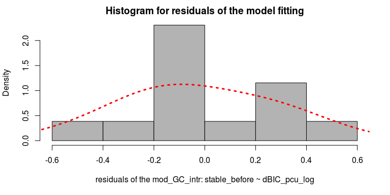

```r
hist(res_GC_stable, prob=TRUE, col='grey70',
     main='Histogram for residuals of the model fitting',
     xlab='residuals of the mod_GC_intr: stable_before ~ dBIC_pcu_log')
lines(density(res_GC_stable, adjust=1.5), col='red', lty='dotted', lwd=3)
```